# Project: Investigate a Dataset - [No-Show Appointments]

- Introduction
- Data Wrangling
- Exploratory Data Analysis
- Conclusions

## Introduction

### Dataset Description

This dataset collects information from 100k medical appointments in Brazil and is focused on the question of whether or not patients show up for their appointment.

Columns included in this dataset:

- **PatientId**: Identification of the patient
- **AppointmentID**: Identification of the Appointment
- **Gender**: Gender Type of patient (M/F)
- **ScheduledDay**: Datetime of appointment registration
- **AppointmentDay**: Datetime of the actual appointment
- **Age**: Age of the patient
- **Neighbourhood**: Patient's neighbourhood
- **Scholarship**: Signify whether the patient is sponsored by the government (True/False)
- **Hipertension**: Indicate whether the patient suffers from Hipertension (True/False)
- **Diabetes**: Indicate whether the patient suffers from Diabetes (True/False)
- **Alcoholism**: Indicate whether the patient deals with alcoholism (True/False)
- **Handcap**: Indicate whether the patient suffers from a disability (True/False)
- **SMS_received**: Indicate whether the patient has recieved reminder SMS (True/False)
- **No-show**: Indicate whether the patient DID NOT attend the appointment (True/False)

### Question(s) for Analysis

1. What is the mean age of the patients who show up vs the patients who doesn't?
2. Does gender play a role in showing up for the appointment?
3. Are sponsored patients more likely to show up for the appointment?
4. What is the pct of patients with chronic illness (Hipertension and/or diabetes) that shows up for appt ?
5. What is the pct of alcoholic patients show up for the appt?
6. What is the pct of alcoholic patients show up for the appt (Gender Based)?
7. Does recieving an SMS increase the chance of showing up for the appt ?
8. What is the highest and lowest neighbourhood in term of attendence?
9. Out of all the neighbourhoods, which gender have the highest/lowest attendance?
10. Is same day appointment met more frequently?
11. Do sponsored handicapped patients make their appointment more frequently?

```python
# Use this cell to set up import statements for all of the packages that you
#   plan to use.
import numpy as np
import pandas as pd
import matplotlib.pyplot as plt
import seaborn as sns
% matplotlib inline
```

```python
# Upgrade pandas to use dataframe.explode() function.
!pip install --upgrade pandas==0.25.0
```

## Data Wrangling

### General Properties

```python
# Load your data and print out a few lines. Perform operations to inspect data
#   types and look for instances of missing or possibly errant data.
df = pd.read_csv('./Database_No_show_appointments/noshowappointments-kagglev2-may-2016.csv')
df.head()
```

|  | PatientId | AppointmentID | Gender | ScheduledDay | AppointmentDay | Age | Neighbourhood | Scholarship | Hipertension | Diabetes | Alcoholism | Handcap | SMS_received | No-show |
| --- | --- | --- | --- | --- | --- | --- | --- | --- | --- | --- | --- | --- | --- | --- |
| 0 | 2.987250e+13 | 5642903 | F | 2016-04-29T18:38:08Z | 2016-04-29T00:00:00Z | 62 | JARDIM DA PENHA | 0 | 1 | 0 | 0 | 0 | 0 | No |
| 1 | 5.589978e+14 | 5642503 | M | 2016-04-29T16:08:27Z | 2016-04-29T00:00:00Z | 56 | JARDIM DA PENHA | 0 | 0 | 0 | 0 | 0 | 0 | No |
| 2 | 4.262962e+12 | 5642549 | F | 2016-04-29T16:19:04Z | 2016-04-29T00:00:00Z | 62 | MATA DA PRAIA | 0 | 0 | 0 | 0 | 0 | 0 | No |
| 3 | 8.679512e+11 | 5642828 | F | 2016-04-29T17:29:31Z | 2016-04-29T00:00:00Z | 8 | PONTAL DE CAMBURI | 0 | 0 | 0 | 0 | 0 | 0 | No |
| 4 | 8.841186e+12 | 5642494 | F | 2016-04-29T16:07:23Z | 2016-04-29T00:00:00Z | 56 | JARDIM DA PENHA | 0 | 1 | 1 | 0 | 0 | 0 | No |

```python
df.shape
```

```
(110527, 14)
```

```python
df.info()
```

```
<class 'pandas.core.frame.DataFrame'>
RangeIndex: 110527 entries, 0 to 110526
Data columns (total 14 columns):
PatientId         110527 non-null float64
AppointmentID     110527 non-null int64
Gender            110527 non-null object
ScheduledDay      110527 non-null object
AppointmentDay    110527 non-null object
Age               110527 non-null int64
Neighbourhood     110527 non-null object
Scholarship       110527 non-null int64
Hipertension      110527 non-null int64
Diabetes          110527 non-null int64
Alcoholism        110527 non-null int64
Handcap           110527 non-null int64
SMS_received      110527 non-null int64
No-show           110527 non-null object
dtypes: float64(1), int64(8), object(5)
memory usage: 11.8+ MB
```

```python
df.duplicated().sum()
```

```
0
```

# Initial Findings

1. The data file was loaded
2. There are 110527 rows
3. There are 14 columns
4. There are no null values in any rows
5. There are no duplicate values in any rows
6. The scheduledDay & AppointmentDay columns will need a change of data type
7. Some other columns might need a change of Data Type to bool

### Data Cleaning

#### First Step of Data Cleaning

Change the data type of ScheduledDay & AppointmentDay to Datetime with the format (Y/M/D)

```python
df['ScheduledDay'] = pd.to_datetime(df.ScheduledDay)
df['ScheduledDay'] = df['ScheduledDay'].dt.strftime('%Y/%m/%d')
df['AppointmentDay'] = pd.to_datetime(df.AppointmentDay)
df['AppointmentDay'] = df['AppointmentDay'].dt.strftime('%Y/%m/%d')
df['ScheduledDay'] = pd.to_datetime(df.ScheduledDay)
df['AppointmentDay'] = pd.to_datetime(df.AppointmentDay)
```

#### Second Step of Data Cleaning

Remove irrelvant data columns that will not be used in this analysis (PatientID & AppointmentID)

```python
df.drop(['PatientId','AppointmentID'], axis=1, inplace=True)
```

#### Third Step of Data Cleaning

Change the data type for (Scholarship, Hipertension, Diabetes, Alcoholism, Handcap, SMS_received) from int to bool

```python
df[['Scholarship','Hipertension','Diabetes','Alcoholism','Handcap','SMS_received']] = df[['Scholarship','Hipertension','Diabetes','Alcoholism','Handcap','SMS_received']].astype('bool')
```

#### Fourth Step of Data Cleaning

Add a column called chronic that will be True if either hypertension or diabetes is True

```python
df['chronic']= np.where(df['Hipertension'] | df['Diabetes'],True,False)
```

#### Fifth Step of Data Cleaning

After the addition of chronic column, there is no need for the separate hibertension & diabetes column, so they will be dropped

```python
df.drop(['Hipertension','Diabetes'], axis=1, inplace=True)
```

#### Sixth Step of Data Cleaning

Add a column called same_day_appt that will be true if the scheduled day is the same as the appointment day

```python
df['same_day_appt']= np.where(((df['AppointmentDay']-df['ScheduledDay']).dt.days)==0,True,False)
```

#### Seventh Step of Data Cleaning

Drop the scheduledDay & AppointmentDay columns since they are no longer relevant to our analysis moving forward

```python
df.drop(['ScheduledDay','AppointmentDay'], axis=1, inplace=True)
```

#### Eighth Step of Data Cleaning

Change the values in No-show column from str to bool

```python
df["No-show"].replace({"No": False, "Yes": True}, inplace=True)
```

#### Final look of the Dataframe:

```python
df.head()
```

|  | Gender | Age | Neighbourhood | Scholarship | Alcoholism | Handcap | SMS_received | No-show | chronic | same_day_appt |
| --- | --- | --- | --- | --- | --- | --- | --- | --- | --- | --- |
| 0 | F | 62 | JARDIM DA PENHA | False | False | False | False | False | True | True |
| 1 | M | 56 | JARDIM DA PENHA | False | False | False | False | False | False | True |
| 2 | F | 62 | MATA DA PRAIA | False | False | False | False | False | False | True |
| 3 | F | 8 | PONTAL DE CAMBURI | False | False | False | False | False | False | True |
| 4 | F | 56 | JARDIM DA PENHA | False | False | False | False | False | True | True |

```python
df.info()
```

```
<class 'pandas.core.frame.DataFrame'>
RangeIndex: 110527 entries, 0 to 110526
Data columns (total 10 columns):
Gender           110527 non-null object
Age              110527 non-null int64
Neighbourhood    110527 non-null object
Scholarship      110527 non-null bool
Alcoholism       110527 non-null bool
Handcap          110527 non-null bool
SMS_received     110527 non-null bool
No-show          110527 non-null bool
chronic          110527 non-null bool
same_day_appt    110527 non-null bool
dtypes: bool(7), int64(1), object(2)
memory usage: 3.3+ MB
```

> Now the data is ready for analysis

## Exploratory Data Analysis

#### Filter rows for the patients that showed up and those who didn't

```python
showed = df['No-show'] == False
noshow = df['No-show'] == True
```

### Research Question 1 (What is the mean age of the patients who show up vs the patients who doesn't? )

```python
df.Age[showed].mean()
```

```
37.790064393252315
```

```python
df.Age[noshow].mean()
```

```
34.31766656212196
```

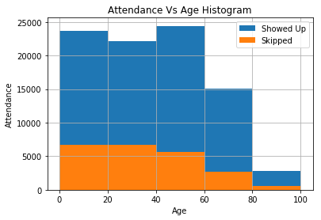

```python
df.Age[showed].hist(alpha=1, bins=[0,20,40,60,80,100], label='Showed Up')
df.Age[noshow].hist(alpha=1, bins=[0,20,40,60,80,100], label='Skipped')
plt.title("Attendance Vs Age Histogram")
plt.ylabel('Attendance')
plt.xlabel('Age')
plt.legend();
```

#### Reasoning:

In this question, the mean age of the patients who showed up for their appointment was calculated vs the mean age of patients who skipped, it was found that patients who skipped their appointment had a general age-mean lower than those who attended (34.32 and 37.8 respectively), a histogram was added to shed more light on the data distribution for all age groups with regards to attendance

### Research Question 2 (Does gender play a role in showing up for the appointment? )

```python
'''
This function was created to simplify and increase the efficency of a great portion of the code in this section
it takes in a column -or a list of columns- to check against the "No-show" column to get the mean of skipping the appointment,
it will then plot the results and return the output for the groupby method.
'''
def mean_and_plot(col):
    df.groupby(col)['No-show'].mean().plot(y="Skipping Mean",x=col,title='{} Vs Attendance'.format(col),kind='bar')
    plt.title('{} vs Skipping'.format(col))
    plt.ylabel('Skipping Mean')
    plt.xlabel(col)
    return df.groupby(col)['No-show'].mean()
```

```
Gender
F    0.203146
M    0.199679
Name: No-show, dtype: float64
```

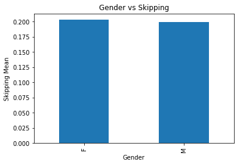

```python
mean_and_plot('Gender')
```

#### Reasoning:

> In this section, a new function was created to calculate and plot the groupby-mean value of a specific column vs the "No-show" column, this function will be used extensively in the following questions.

For this question, the gender of the patients was analysed and the data suggested that there is virtually little to no indication that gender -on its own- plays a role in predicting whether the patient will attend vs skip their appointment (a bar graph was added to clarify the data)

### Research Question 3 (Are sponsored patients more likely to show up for the appointment? )

```
Scholarship
False    0.198072
True     0.237363
Name: No-show, dtype: float64
```

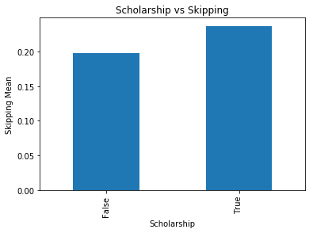

```python
mean_and_plot('Scholarship')
```

#### Reasoning:

For this question, I explored whether sponsored patients are more likely to attend their appointment, the data however suggested otherwise with the sponsored patients seeming to be missing their appointment compared to their non-sponsored counterparts, this was an interesting find, and it opens the door to further questions, whether the sponsored patient feels more comfortable skipping an appointment if they can as easily secure another, or maybe the sponsored patients indicate a level of economic hardship that might be a factor in them not being able to meet their appointment more frequently, the possibilities are endless, and the data provided isn't enough to explore them all (**Data Limitation**)

### Research Question 4 (What is the pct of patients with chronic illness (Hipertension and/or diabetes) that shows up for appt ? )

```
chronic
False    0.209215
True     0.174607
Name: No-show, dtype: float64
```

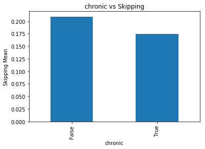

```python
mean_and_plot('chronic')
```

```python
'''
This function takes in a column as parameter and calculates the percentage of attendance for that specific column (i.e chronic patients , alcoholic patients, ...etc),
plots a bar graph of attendance vs skipped and return the percentage of attendance
'''
def pct_att(var):
    filtered_df=df[var]==True
    total_num = filtered_df.sum()
    num_attended = total_num - df['No-show'][filtered_df].sum()
    num_skipped = df['No-show'][filtered_df].sum()
    pct_attended = num_attended * 100 / total_num
    x = ['Attended','Skipped']
    y = [num_attended,num_skipped]
    plt.title("{} Patients Attendance".format(var))
    plt.ylabel('Number of patients')
    plt.xlabel('Attendance')
    plt.bar(x,y)
    return pct_attended
```

```
82.53934130191762
```

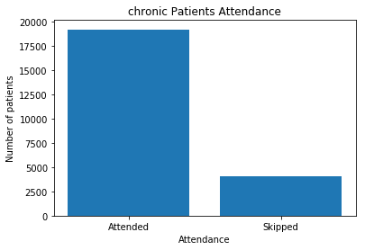

```python
pct_att('chronic')
```

#### Reasoning:

> This section introduces another function that takes in a column name, and calculate the percentage of attendees in this column, and plots a bar graph to showcase it

This question explores 2 statistics, the first one is the mean of skipping an appointment for patients suffering from a chronic disease (Hypertension and/or Diabetes) vs patients who don't, and the data suggests that chronic patiens are more likely to show up for their medical appointment which was quite the intutive assumption, the second part dives deeper into the chronic patients data to get the exact percentage of the attending patients vs the skipping ones, and the value is 82.54% which is pretty high

### Research Question 5 (What is the pct of alcoholic patients show up for the appt? )

```
Alcoholism
False    0.201946
True     0.201488
Name: No-show, dtype: float64
```

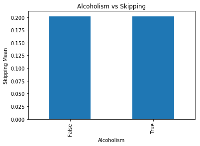

```python
mean_and_plot('Alcoholism')
```

```
79.85119047619048
```

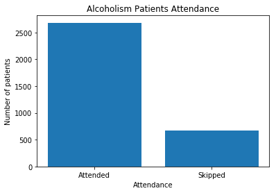

```python
pct_att('Alcoholism')
```

#### Reasoning:

This question explores 2 statistics, the first one is the mean of skipping an appointment for patients suffering from Alcoholism vs patients who don't, and the data suggests that alcoholism -on its own- doesn't play a role in determining whether the patient will attend their appointment or not (the means were near equal), the second part dives deeper into the alcoholic patients data to get the exact percentage of the attending patients vs the skipping ones, and the value is 79.85%

### Research Question 6 (What is the pct of alcoholic patients show up for the appt (Gender Based)? )

```
Alcoholism  Gender
False       F         0.202303
            M         0.201259
True        F         0.251840
            M         0.172672
Name: No-show, dtype: float64
```

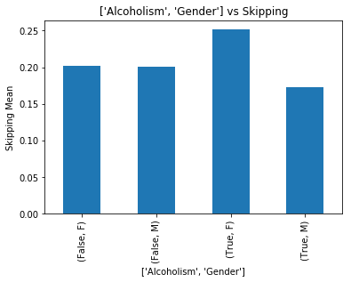

```python
mean_and_plot(['Alcoholism','Gender'])
```

#### Reasoning:

This questions takes the analysis in the previous question a little bit further, diving deeper into a more granual characteristics of the alcoholic patients and taking gender into consideration, the results are quire interesting as it indicated that male alcoholic patients are the "most" likely to attend their appointment while the female alcoholics are the most likely to skip it.

### Research Question 7 (Does recieving an SMS increase the chance of showing up for the appt?)

```
SMS_received
False    0.167033
True     0.275745
Name: No-show, dtype: float64
```

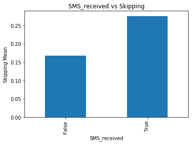

```python
mean_and_plot('SMS_received')
```

#### Reasoning:

This question is pretty "Out-there", it explores whether the patients who recieved a reminder SMS are more likley to make their appointment, and -to my surprise- the data indicated a resounding **NO**, Obviously these results doesn't indicate whatsoever that getting an SMS reminder actively causes the patients to skip their appointment, it was just a funny correlation, however it doesn't imply causation

### Research Question 8 (What is the highest and lowest neighbourhood in term of attendence?)

```python
df.groupby('Neighbourhood')['No-show'].mean().idxmax()
```

```
'ILHAS OCEÂNICAS DE TRINDADE'
```

```python
df.groupby('Neighbourhood')['No-show'].mean().idxmin()
```

```
'PARQUE INDUSTRIAL'
```

#### Reasoning:

This question explored which neighbourhood had the most patients making their appointment and which neighbourhood had the least, the neighbourhood with the most attendance was PARQUE INDUSTRIAL while the least was ILHAS OCEÂNICAS DE TRINDADE

### Research Question 9 (Out of all the neighbourhoods, which gender have the highest/lowest attendance?)

```python
df.groupby(['Neighbourhood','Gender'])['No-show'].mean().idxmax()
```

```
('ILHAS OCEÂNICAS DE TRINDADE', 'F')
```

```python
df.groupby(['Neighbourhood','Gender'])['No-show'].mean().idxmin()
```

```
('AEROPORTO', 'M')
```

#### Reasoning:

This question added Gender to the equation of the previous one, and eventhough the neighbourhood with the least attendees remained the same with Females missing the most appointments in that neighbourhood, the highest attendance award went to males in AEROPORTO

### Research Question 10 (Is same day appointment met more frequently?)

```
same_day_appt
False    0.285240
True     0.046469
Name: No-show, dtype: float64
```

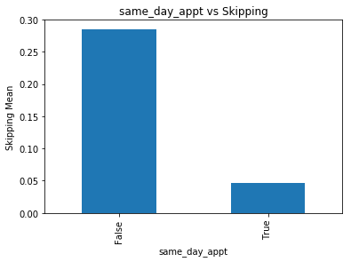

```python
mean_and_plot('same_day_appt')
```

#### Reasoning:

This question was a favorite one of mine, it required the addition of a new column that tracks whether the appointment was booked on the same day as the appointment itself, and then getting the mean of skipping appointments for same-day-appointment vs other kinds of appointments. The data results indicated that same-day-appointments are much **MUCH** more likely to be met which very closly matched the assumption I had prior to analysing the data.

### Research Question 11 (Do sponsored handicapped patients make their appointment more frequently?)

```
Scholarship  Handcap
False        False      0.198375
             True       0.183713
True         False      0.238697
             True       0.157303
Name: No-show, dtype: float64
```

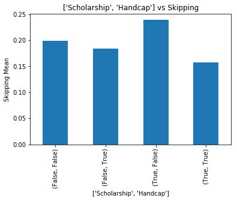

```python
mean_and_plot(['Scholarship','Handcap'])
```

#### Reasoning:

This question revists the data about sponsored patients, our previous findings indicated that sponsored patients are more likely to skip their appointment, so I thought I would throw "handicapped" characteristics into the mix and see if that makes a change. The Data indicated a very interesting piece of information: Handicapped patients -whether sponsored or not- are more likely to attend their appointment, with the sponsored handicapped patients being the most likely to attend, while the sponsored non-handicapped patients being the least likely to attend.

## Conclusions

Analysing this data has yielded some interesting findings, I'll present the findings as answers to the previously stated questions in the introduction

1. What is the mean age of the patients who show up vs the patients who doesn't?
   - The mean age of the patients who show up is 37.8 years old, while the mean age of the patients who skip their appointment is 34.32 years old
2. Does gender play a role in showing up for the appointment?
   - Based on the data, it seems that gender -on its own- plays little to no role in indicating whether the patient will attend the appointment
3. Are sponsored patients more likely to show up for the appointment?
   - Taking the sponsorship data on its own, the data indicates that there is a higher chance for a sponsored patient to SKIP their appointment
4. What is the pct of patients with chronic illness (Hipertension and/or diabetes) that shows up for appt ?
   - Chronic patients are more likely to attend their appointment, around 82.54% of chronic patients do
5. What is the pct of alcoholic patients show up for the appt?
   - Alcoholism doesn't clearly indicate whether it'll affect whether a patient will attend or skip the appointment, around 80% of alcoholic patients attend their appointment
6. What is the pct of alcoholic patients show up for the appt (Gender Based)?
   - When adding gender to the equation, the data suggests that alcoholic females are more likely to SKIP their appointment compared to alcoholic males and both non-alcoholic males and females
7. Does recieving an SMS increase the chance of showing up for the appt ?
   - According to the Data, those who recieved an sms were more likely to skip their appointment, however there are simply not enough data to prove this, as corelation doesn't imply causation (**Data Limitation**)
8. What is the highest and lowest neighbourhood in term of attendence?
   - The highest neighbourhood in term of attendance is PARQUE INDUSTRIAL
   - The lowest neighbourhood in term of attendance is ILHAS OCEÂNICAS DE TRINDADE
9. Out of all the neighbourhoods, which gender have the highest/lowest attendance?
   - when bringing gender into the equation, ILHAS OCEÂNICAS DE TRINDADE remains the lowest in term of attendance with females as the lowest attendees
   - On the other hand, the highest attendance changes to Males in AEROPORTO
10. Is same day appointment met more frequently?
    - Same-Day appointment are met **Significantly** more frequently which was a very interesting find
11. Do sponsored handicapped patients make their appointment more frequently?
    - Even though in an earlier question, there was an indication that sponsored patients are more likely to skip their appointment, upon checking the data against handicapped patients as well, I found that sponsored handicapped patients are the least likely to skip their appointment out of that specific group

```python
from subprocess import call
call(['python', '-m', 'nbconvert', 'Investigate_a_Dataset.ipynb'])
```

```
0
```